# CMorgan_Livesession2assignment

ChrisMorgan

January 21, 2018

## Questions 1

#### What is a basic workflow for reproducible research

The basic workflow can be seen below (image taken from reproducible research with R and R Studio by Christopher Gandrud). It consists of a user taking raw data from multiple sources and being able to go backwards and forward between data gathering, analysis, and forms of presentation.

image:

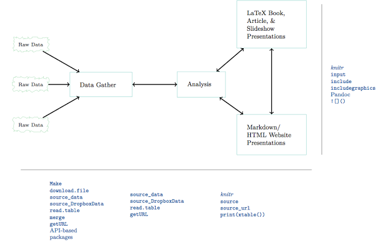

#### What are five practical tips for making research reproducible?

1. Document everything
2. Everything is a (text) file
3. All files should be human readable
4. Explicitly tie your files together
5. Have a plan to organize, store, and make your files available

#### Give an example of how you might implment each tip

1. Record your session info so future users can diagnoses potential conflicts.
2. Utilize text files since they are future proof and anyone can open one.
3. Comment frequently in your code so other users, or you, can understand how it works.
4. Utilize tie commands to keep your files working together.
5. Limit content in files so you end up with readable parts and not a giant mess of a “master program”.

#### Which one of these do you think will be the most difficult?

I personally think remembering to make files human readable is the hardest because it requires the user to be conscious of how they comment and organize their code. This requires a level of practice to become habit and it is something i will personally focus on.

## Question 2

#### Air Quality question 2 part a

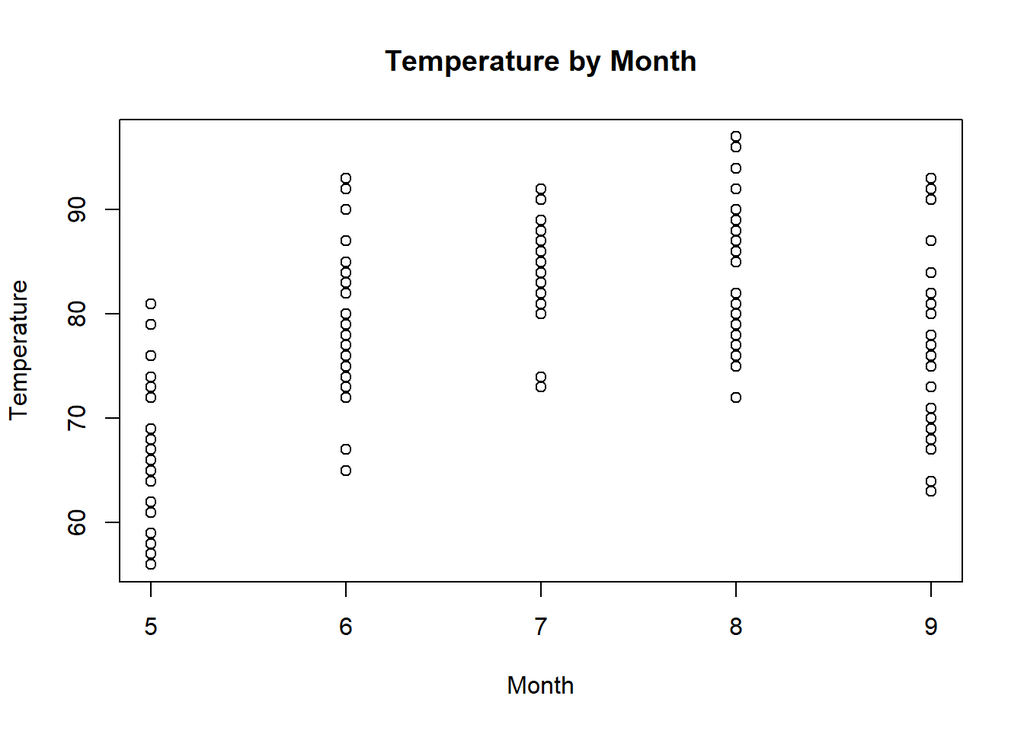

```r
plot(x=airquality$Month, y=airquality$Temp,
     xlab = "Month", ylab="Temperature", title("Temperature by Month"))
```

#### Air Quality question 2 part b

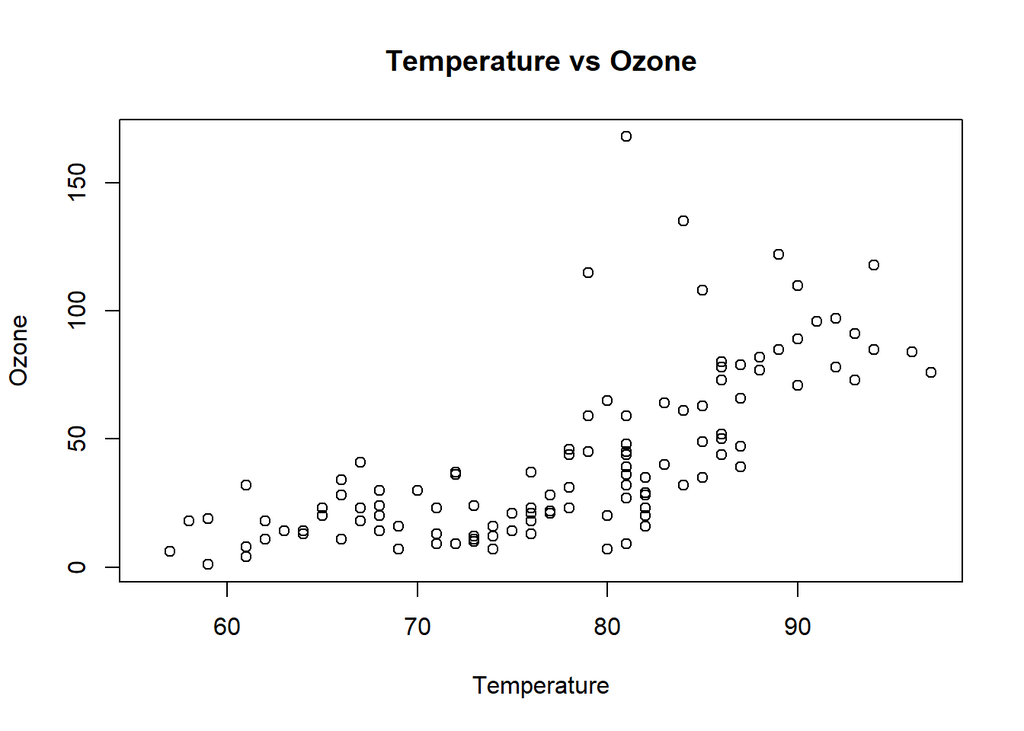

```r
plot(x=airquality$Temp, y=airquality$Ozone,
     xlab = "Temperature", ylab="Ozone", title("Temperature vs Ozone"))
```

#### Air Quality question 2 part c

Completed through portion a & b above…

## Question 3

#### Cars question 3 part a

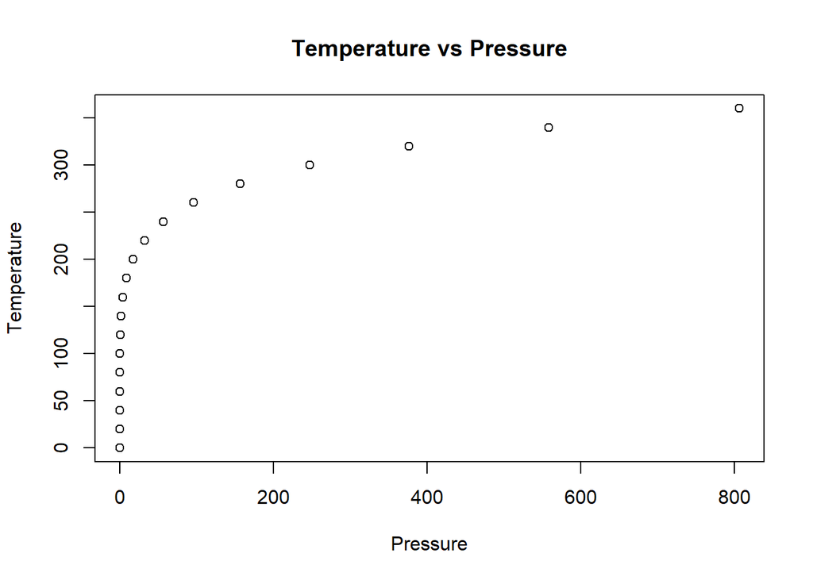

```r
plot(x=pressure$pressure,y=pressure$temperature, title("Temperature vs Pressure"),
     xlab = "Pressure", ylab = "Temperature")
```

#### Cars question 3 part b

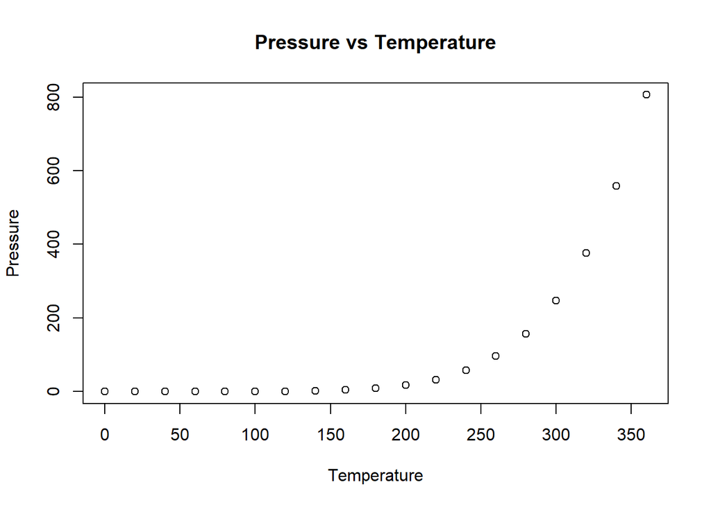

```r
plot(x=pressure$temperature,y=pressure$pressure, title("Pressure vs Temperature"),
     xlab = "Temperature", ylab = "Pressure")
```

#### cars question 3 part c

Completed through portion a & b above…

#### Swirl question 4

Please see “Cmorganswirl8-11.txt”